# Cotingency analyses

Chapter 12

**Today’s investigation.** Dominance rank is a key index of social status in animals. For example, higher dominance rank may improve life outcomes because it is associated with better access to material, social, and embodied ‘wealth’. As such, it has key parallels with indices of status in human societies. A current question of interest is whether animals that are socially disadvantaged, or that have low social status, present poorer health than those higher in the social ladder, as observed in many human populations. Today we will use *contingency analysis* to test associations between two categorical variables: dominance rank and health status.

Introduction

In this lab, we will carry out a *contingency test* to determine associations between dominance rank (i.e., high, low) and health status (i.e., healthy, unhealthy), two categorical variables. Prominent theories within the human life course perspective propose that health declines are exacerbated in low-status individuals, relative to high-status ones. Cumulative evidence points towards similar patterns among other non-human social animals. Today, we will use simulated data of rhesus macaque monkeys to test whether showing poor performance in cognition differs according to social status.

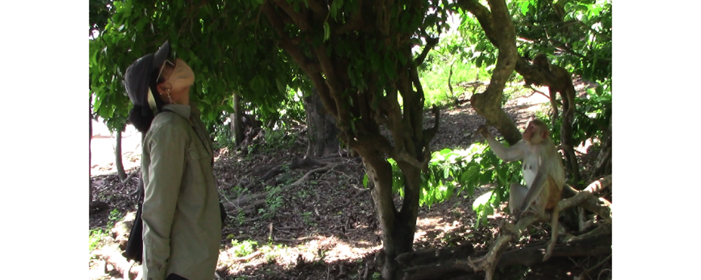

**Figure 1.** Graduate student A Diaz performs a gaze-following cognitive task on a rhesus macaque monkey. If the monkey followes her gaze (as shown), the monkey is classified as ‘healthy’. If the monkey fails to co-orient with her the monkey is classified as ‘unhealthy’.

**Upon completion of this lab, you should be able to:**

- Estimate the $\chi^2$ test statistic;
- Test hypotheses about associations between two categorical variables using a contingency test.

Worked example

When testing associations between two categorical variables, we employ a contingency analyses. In particular, these analyses make use of *contingency tables* that display how the frequencies of different values of one categorical variable *depend* on the value of another categorical variable. As such, this contingency analysis is also known as $\chi^2$ test of independence. Let’s work on a step-by-step example.

The $\chi^2$ contingency test assumes:

- the data comes from a random sample from a population
- the sampling distribution of the $\chi^2$ statistic follows a $\chi^2$ distribution
- no category should have an expected frequency < 1
- no more than 20% of the categories should have an expected frequencies < 5

## The $\chi^2$ statistic

The $\chi^2$ statistic measures how much your observed categorical data differ from what you would expect to find by chance alone. Here, we are interested in testing the following hypotheses:

- $H_0$: Cognitive health performance and social status are not associated (i.e., are independent)
- $H_A$: Cognitive health performance and social status are associated (i.e., are not independent)

For our example, a significant association would indicate that cognitive performance and social status are not independent However, this does not necessarily implies that a lower social status *causes* monkeys to perform poorly because the contingency test says nothing about causality.

The $\chi^2$ statistic is defined as
$$\begin{aligned}
\chi^2 =\sum_{row=1}^{r}\sum_{column=1}^{c}\frac{[Observed(row,column) -
Expected(row,column)]^2} {Expected(row,column)},
\end{aligned}$$

where *Observed(row,column)* is the frequency of individuals observed in a particular row and column of the contingency table, and *Expected(row,column)* is the frequency expected in that same category under the null hypothesis. Note that the numerator in this equation is squared so that positive and negative deviations between observed and expected frequencies are treated equally.

Now that we have defined the test statistic, let’s perform each step of a contingency test.

Say that we have the following data of rhesus macaques:

**Table 1.** Observed frequencies of healthy and unhealthy monkeys across social status.

| Cognition | High social status | Low social status |
| --- | --- | --- |
| Healthy | 37 | 9 |
| Unhealthy | 3 | 31 |

The **Table 1** is a 2 *x* 2 contingency table because it has 2 rows and 2 columns. In this case, our response variable (measured cognitive state) is positioned across rows, while our explanatory variable (social status) is positioned across columns. The data is based on *N* = 80 monkeys (the sum of all categories in the table). Note that at this point we already have the information to input the *Observed(row,column)* terms in the $\chi^2$ statistic equation above. For example, the observed frequency of healthy monkeys of high status (position row=1 and column=1 in the contingency table or *Observed(1,1)* in the $\chi^2$ equation) is 37.

However, we also need 2 *x* 2 contingency table with *expected* frequencies assuming independence:

**Table 2.** Expected frequencies of healthy and unhealthy monkeys across social status.

| Cognition | High social status | Low social status |
| --- | --- | --- |
| Healthy | ? (row=1,column=1) | ? (row=1,column=2) |
| Unhealthy | ? (row=2,column=1) | ? (row=2,column=2) |

**1. Estimating the expected frequencies assuming independence**

**Step A.** Estimate sample sizes across rows and columns.

First, estimate the sample size of each group of your data. Note that the total (global) sample size is *N* = 80 monkeys.

| Cognition | High social status | Low social status | Total |
| --- | --- | --- | --- |
| Healthy | 37 | 9 | 46 |
| Unhealthy | 3 | 31 | 34 |
| Total | 40 | 40 | N = 80 monkeys |

**Step B.** Estimate probabilities across categories.

First, estimate the probability that a randomly sampled monkey is healthy. Second, estimate the probability that a randomly sampled monkey is of high social status.
$$\begin{aligned}
\Pr[healthy]=46/80 =0.575 \\
\Pr[high \ status]=40/80 =0.500
\end{aligned}$$

**Step C.** Estimate the probability of both events occurring at the same time.

Note that for each position in the contingency table, two events must occur. Because this involves an *and statement* in probability, we need to use the multiplication rule.

Estimate the probability that a randomly sampled monkey is healthy *and* of high status (i.e., position row=1, column=1 in the contingency table).
$$\Pr[healthy \ and \ high \ status]=0.575 * 0.500 =0.288$$

**Step D.** Estimate the expected frequency.

So, under the null hypothesis, we expect 23 out of 80 monkeys to be healthy and to have high social status:

Expected frequencies of healthy and unhealthy monkeys across social status.

| Cognition | High social status | Low social status |
| --- | --- | --- |
| Healthy | 23 | ? |
| Unhealthy | ? | ? |

If you do the same steps for the other three positions in the contingency table, you will obtain the following expected frequencies:

**Table 3.** Expected frequencies of healthy and unhealthy monkeys across social status.

| Cognition | High social status | Low social status |
| --- | --- | --- |
| Healthy | 23 | 23 |
| Unhealthy | 17 | 17 |

Note that the fact that frequencies across rows are identical in this example does not mean that they will always be identical. However, samples sizes across groups, as well as the global *N*, must be identical to your observed frequencies.

**2. Estimating the $\chi^2$ statistic**

Substituting the $\chi^2$ equation above, we yield:
$$\begin{aligned}
\chi^2 =\frac{(37-23)^2} {23}+\frac{(3-17)^2} {17}+\frac{(9-23)^2}
{23}+\frac{(31-17)^2} {17}=40.1
\end{aligned}$$

**3. Estimating the range of the *p*-value**

The degrees of freedom for the $\chi^2$ contingency test specifies which $\chi^2$ distribution to use as the null distribution. Here, they are defined as
$$\begin{aligned}
\ df =(nrows-1)(ncolumns-1)=(2-1)(2-1)=1,
\end{aligned}$$
where nrow and ncolumn represent the number of rows and columns, respectively. In this way, a 2 *x* 2 contingency table analysis will always have *df* = 1. We need to use the $\chi^2$ distribution with 1 degree of freedom as the null distribution to estimate the range of the *p*-value. After revising the statistical table, the critical $\chi^2$ at a significance level = 0.05 is 3.84.

**4. Conclusions**

Because our calculated $\chi^2$ is more extreme than the critical $\chi^2$, we reject the null hypothesis and conclude that the expected frequencies of monkeys across health state and social status are different from the observed ones ($\chi^2$ = 40.1, df =1, *p*<0.05). We reject the null hypothesis.